# Assignment 7 - Structural Topic Modeling (Problems 1 & 2)

Stephen Pasco

2025-10-31

```r
library(stm)
library(SnowballC)
library(wordcloud)
library(tm)
library(ggplot2)
library(scales)
```

```r
# Helper function: Min-max normalization to [0, 1] scale
# This function rescales a numeric vector to the range [0, 1]
# Used for combining metrics with different scales (e.g., coherence and exclusivity)
normalize_metric <- function(x) {
  x_min <- min(x, na.rm = TRUE)
  x_max <- max(x, na.rm = TRUE)

  # Handle edge case where all values are identical
  if (x_max == x_min) {
    return(rep(0.5, length(x)))
  }

  (x - x_min) / (x_max - x_min)
}
```

# Part A: Data Preparation

## Loading the Dataset

```r
# Load the hotel reviews dataset
hotel_data <- read.csv("data/hotel_reviews.csv", stringsAsFactors = FALSE)

# Validate data integrity
stopifnot(
  "Data file must contain Review column" = "Review" %in% names(hotel_data),
  "Data file must contain Rating column" = "Rating" %in% names(hotel_data),
  "Dataset must not be empty" = nrow(hotel_data) > 0,
  "Reviews must not be empty strings" = all(nchar(trimws(hotel_data$Review)) > 0),
  "Ratings must be between 1 and 5" = all(hotel_data$Rating >= 1 & hotel_data$Rating <= 5)
)

cat("Dataset loaded successfully:", nrow(hotel_data), "reviews\n")
```

```
## Dataset loaded successfully: 20491 reviews
```

## Text Preprocessing

```r
# Extract reviews and ratings
reviews <- hotel_data$Review
ratings <- hotel_data$Rating

# Preprocess text using textProcessor
processed <- textProcessor(
  documents = reviews,
  metadata = data.frame(rating = ratings),
  lowercase = TRUE,
  removestopwords = TRUE,
  removenumbers = TRUE,
  removepunctuation = TRUE,
  stem = TRUE,
  wordLengths = c(3, Inf)
)
```

```
## Building corpus...
## Converting to Lower Case...
## Removing punctuation...
## Removing stopwords...
## Removing numbers...
## Stemming...
## Creating Output...
```

```r
# Prepare documents
# lower.thresh = 10 removes terms appearing in < 10 documents (~0.05% of corpus)
# This filters out extremely rare terms that may be typos or noise while
# preserving domain-specific vocabulary
out <- prepDocuments(
  documents = processed$documents,
  vocab = processed$vocab,
  meta = processed$meta,
  lower.thresh = 10
)
```

```
## Removing 56088 of 62535 terms (96679 of 1527260 tokens) due to frequency
## Your corpus now has 20491 documents, 6447 terms and 1430581 tokens.
```

```r
docs <- out$documents
vocab <- out$vocab
meta <- out$meta
```

# Part B: STM Model Implementation

## Running selectModel()

We run `selectModel()` to fit multiple STM models with 3 topics, using Rating as a prevalence covariate. The function performs multiple random initializations to help us select the best model based on semantic coherence and exclusivity.

```r
set.seed(42)

# Run selectModel with 3 topics and Rating as covariate
models <- selectModel(
  documents = docs,
  vocab = vocab,
  K = 3,
  prevalence = ~ rating,
  max.em.its = 75,
  data = meta,
  runs = 10,
  seed = 42
)
```

## Model Selection: Semantic Coherence vs Exclusivity

Semantic coherence measures how often the top words in a topic co-occur in documents (higher is better). Exclusivity measures how distinctive a topic’s words are compared to other topics (higher is better). We want a model that balances both metrics.

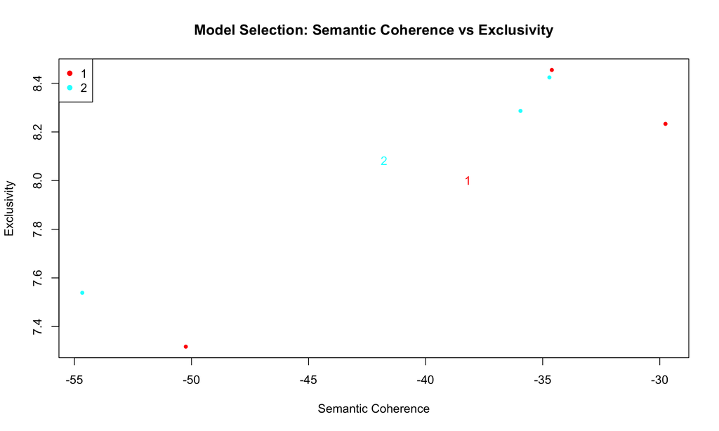

```r
# Plot semantic coherence vs exclusivity
plotModels(models)
title("Model Selection: Semantic Coherence vs Exclusivity")
```

## Select the Best Model

We select the model with the best balance between semantic coherence and exclusivity. Typically, we want high values for both, but there’s often a trade-off.

```r
# Select the model with highest average of normalized coherence and exclusivity
coherence <- unlist(lapply(models$runout, function(x) mean(semanticCoherence(x, docs))))
exclusivity <- unlist(lapply(models$runout, function(x) mean(exclusivity(x))))

# Normalize to [0,1] scale using helper function
coherence_norm <- normalize_metric(coherence)
exclusivity_norm <- normalize_metric(exclusivity)

# Combined score (equal weighting)
combined_score <- coherence_norm + exclusivity_norm
best_model_idx <- which.max(combined_score)

# Extract the best model
stm_model <- models$runout[[best_model_idx]]
```

# Part C: Results Analysis

## Top 7 Words for Each Topic

```r
# Extract top words for each topic
top_words <- labelTopics(stm_model, n = 7)

cat("Top 7 words for each topic:\n\n")
```

```
## Top 7 words for each topic:
```

```r
for (i in 1:3) {
  cat("Topic", i, ":\n")
  cat("  FREX words:", paste(top_words$frex[i,], collapse = ", "), "\n")
  cat("  Highest prob:", paste(top_words$prob[i,], collapse = ", "), "\n\n")
}
```

```
## Topic 1 :
##   FREX words: desk, charg, confirm, smoke, carpet, wall, phone
##   Highest prob: room, hotel, stay, night, bed, servic, desk
##
## Topic 2 :
##   FREX words: beach, resort, punta, cana, entertain, activ, dominican
##   Highest prob: beach, resort, pool, food, day, great, time
##
## Topic 3 :
##   FREX words: metro, pari, florenc, rambla, london, museum, modern
##   Highest prob: hotel, stay, room, great, locat, staff, good
```

## Word Clouds for Each Topic

Word clouds visualize the most prevalent words in each topic, with size reflecting word importance.

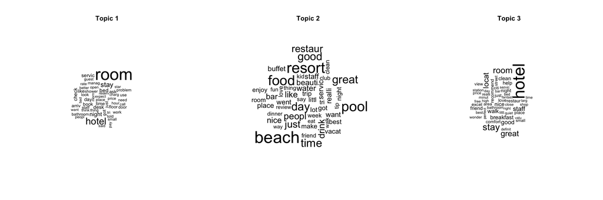

```r
# Create word clouds for each topic
par(mfrow = c(1, 3))
for (i in 1:3) {
  cloud(stm_model, topic = i, scale = c(3, 0.5), max.words = 50)
  title(paste("Topic", i), line = 1)
}
```

```r
par(mfrow = c(1, 1))
```

## Top 5 Reviews for Each Topic

These are the reviews most strongly associated with each topic.

```r
# Find top reviews for each topic
for (i in 1:3) {
  cat("\n", rep("=", 80), "\n", sep = "")
  cat("Topic", i, "- Top 5 Reviews:\n")
  cat(rep("=", 80), "\n\n", sep = "")

  thoughts <- findThoughts(stm_model, texts = reviews, topics = i, n = 5)

  # Get the indices (thoughts$index is a list)
  indices <- thoughts$index[[1]]

  # Safety check: ensure we have valid data
  n_available <- min(5, length(indices), length(thoughts$docs[[1]]))

  if (n_available == 0) {
    cat("No reviews found for this topic.\n\n")
    next
  }

  for (j in 1:n_available) {
    cat("Review", j, "(Rating:", meta$rating[indices[j]], "):\n")
    # Show first 400 characters of each review (word-boundary aware)
    review_text <- as.character(thoughts$docs[[1]][j])
    truncated <- substr(review_text, 1, 400)
    # Add ellipsis only if text was actually truncated
    if (nchar(review_text) > 400) {
      cat(truncated, "...\n\n")
    } else {
      cat(review_text, "\n\n")
    }
  }
}
```

```
##
## ================================================================================
## Topic 1 - Top 5 Reviews:
## ================================================================================
##
## Review 1 (Rating: 1 ):
## horrible customer service worst hilton possibly worst hotel, trying review guidelines feel important people know kinds business practices ran into.we stayed hilton nights second night having wedding reception hilton.all booking went smoothly room decent exectutive sweet not overpriced got discoun…
##
## Review 2 (Rating: 1 ):
## worst place stayed started just fine, greeted nice receptionist gave early check, not told renovations taking place floors noise level horrendous, did not sign warning hazardous chemicals harmful health cause birth defects pregnancy checked, inquired desk receptionist told knew nothing, area nast…
##
## Review 3 (Rating: 1 ):
## horrible experience customer service live 20 minutes hotel reservations birthday stay close proximity clubs/bars frequent, weekend birthday torrential rainstorm overnight stay just did n't like good idea, called toll free reservation hotline happen canceled reservation, center n't reservation tra…
##
## Review 4 (Rating: 1 ):
## save money hostel, booked night stay january standard room starting thursday, checking unfriendly receptionist went small dirty room, scuffed walls clearly hairs sheets make-up pillowcases holes towels, speaking receptionist requesting new room current room cleaned told no option wait monday mana…
##
## Review 5 (Rating: 1 ):
## worst experience hotel, hotel claim online service kicker, reservations hotels.com not honored whim rude night manager edwin moore, refused contact hotels.com resolve issue demanded guest self pay extra stay, verifying reservations day actual hotel desk staff, resigned check paying addition price…
##
##
## ================================================================================
## Topic 2 - Top 5 Reviews:
## ================================================================================
##
## Review 1 (Rating: 5 ):
## ca n't wait till year, 2nd 16th 2008we stayed lofts week 3 adults allow 2 adults suite rs.the second willis maribell fantastic, tipped simply deserved it.the grounds beautiful fact groundsthrough entire resort magnificent.picture perfect beach pool lobby just everywhere.the second wk.we stayed rs…
##
## Review 2 (Rating: 5 ):
## secrets excellence truly excellente, husband just returned 5 amazing days secrets, loved minute fabulous vacation, read reviews went admit nervous, decided make opinion glad did, thought food excellent, went honeymoon mexico iberostar playa del carmen thought food 100 better, loved bite, highly r…
##
## Review 3 (Rating: 5 ):
## incredible place husband went night day stay punta cana booked adventure tours, tour guide lisa england punta cana years, helpful friendly, iberostar bavaro truly star inclusive premium alcohol, yes plenty ages games bingo ping pong pool tables painting ceramics excellent massages beach learning …
##
## Review 4 (Rating: 4 ):
## relaxing vacation husband went melia caribe tropical 1st anniversary, did not royal service not regret, pros cons vacation start cons really did not like food, best meal day breakfast, went buffet caribe pool, pancakes waffles best loved fresh squeezed oj, really dissapointed food, ate specialty …
##
## Review 5 (Rating: 5 ):
## absolutely terrific, let tell prior leaveing vacation little concerned negative reviews read, like stayed, great time resort terrific, got hot cloudy windy, went 7 nights day weather got better better, hot single day, days wind cloudy hot, rained twice, early morning 6:30a time got 9am know raine…
##
##
## ================================================================================
## Topic 3 - Top 5 Reviews:
## ================================================================================
##
## Review 1 (Rating: 5 ):
## perfect city centre madrid hotel perfect place city break madrid, group 2 mothers 4 teenagers twin bedded rooms comfy beds 6th floor perfect, hotel brilliantly located city break metro 10 steps hotel entrance, shops restaurants close madrid vision tourist bus stop minute walk away, not recommend …
##
## Review 2 (Rating: 5 ):
## little gem enjoyed stay excellent hotel 21 year old daughter recently, impressed friendliness efficiency proprietors, arrival presented map florence major tourist attractions location good restaurants pointed, bedroom en-suite bathroom spacious clean nicely decorated, nice buffet breakfast provid…
##
## Review 3 (Rating: 5 ):
## loved casa fuster hotel thrilled stay casa fuster hotel, accompanied husband business trip hotel arrangements, hotel location great easy walking city sights nice quiet safe area, room faced inside courtyard extremely quiet comfortable, staff helpful spoke english, favorite restaurant nearby la po…
##
## Review 4 (Rating: 5 ):
## classy comfortable best paris, just returrned european trip stay paris highlight memorable excellence hotel grand hommes exceeded expectations respects apart room size, hotel ideally positioned latin quarter opposite teh pantheon walking distance countless restaurants river public transport.the r…
##
## Review 5 (Rating: 5 ):
## great hotel friend stayed hotel fusion sept 26 2 nights, great location close union square cable car turnaround near visitor centre bart, rooms clean bit small nicely decorated, staff friendly helpful, free breakfast 7am 930am muffins bread toast crossants juice coffee tea, great experince hotel …
```

## Topic Labels

Based on the top words and representative reviews above, assign interpretive labels:

```r
topic_labels <- c(
  "Topic 1" = "Room Quality and Service Complaints",
  "Topic 2" = "Beach Resort Amenities and Activities",
  "Topic 3" = "City Hotel Location and Access"
)

for (i in 1:3) {
  cat("Topic", i, ":", topic_labels[i], "\n")
}
```

```
## Topic 1 : Room Quality and Service Complaints
## Topic 2 : Beach Resort Amenities and Activities
## Topic 3 : City Hotel Location and Access
```

# Part D: Visualization and Interpretation

## Topic Prevalence

This plot shows the overall prevalence (frequency) of each topic across all reviews.

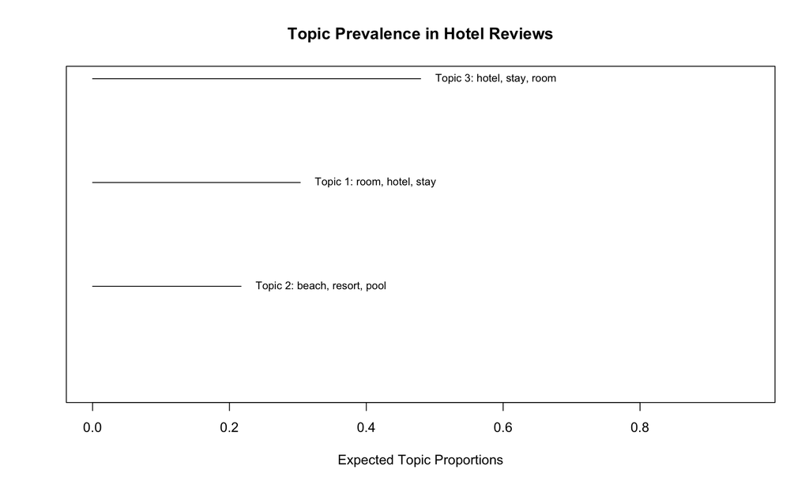

```r
# Plot topic prevalence
plot(stm_model, type = "summary", text.cex = 0.8, main = "Topic Prevalence in Hotel Reviews")
```

## Effect of Rating on Topic Prevalence

We use `estimateEffect()` to model how ratings influence the prevalence of each topic.

```r
# Estimate the effect of rating on topic prevalence
effects <- estimateEffect(
  formula = 1:3 ~ rating,
  stmobj = stm_model,
  metadata = meta,
  uncertainty = "Global"
)
```

## Visualizing Rating Effects

These plots show how topic prevalence changes with different ratings.

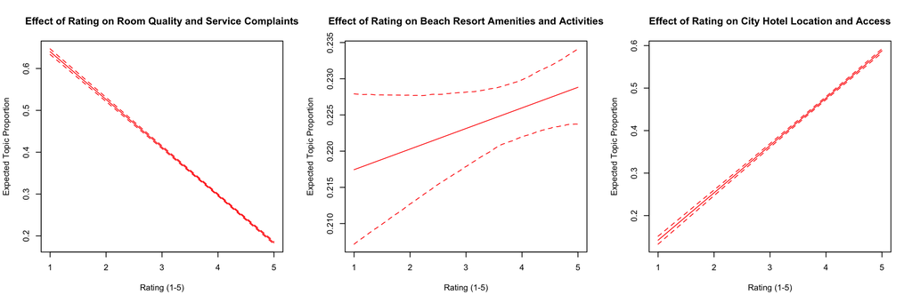

```r
# Plot the effect of rating on each topic
par(mfrow = c(1, 3))
for (i in 1:3) {
  plot(
    effects,
    covariate = "rating",
    topics = i,
    model = stm_model,
    method = "continuous",
    xlab = "Rating (1-5)",
    main = paste("Effect of Rating on", topic_labels[i]),
    xlim = c(1, 5),
    printlegend = FALSE
  )
}
```

```r
par(mfrow = c(1, 1))
```

## What Customers Value vs Dislike

```r
for (topic_num in 1:3) {
  topic_summary <- summary(effects, topics = topic_num)
  rating_coef <- topic_summary$tables[[1]][2, "Estimate"]
  rating_pval <- topic_summary$tables[[1]][2, "Pr(>|t|)"]

  cat("Topic", topic_num, "- Rating Coefficient:", round(rating_coef, 5),
      "(p =", format.pval(rating_pval, digits = 3), ")")

  if (rating_coef > 0) {
    cat(" - Valued by customers\n")
  } else {
    cat(" - Disliked by customers\n")
  }
}
```

```
## Topic 1 - Rating Coefficient: -0.11424 (p = <2e-16 ) - Disliked by customers
## Topic 2 - Rating Coefficient: 0.00277 (p = 0.0873 ) - Valued by customers
## Topic 3 - Rating Coefficient: 0.11146 (p = <2e-16 ) - Valued by customers
```

# Part E: Problem 2 - Determining Optimal Number of Topics with searchK()

## Overview

In Problem 1, we used `selectModel()` with a fixed K=3 topics. Now in Problem 2, we systematically determine the optimal number of topics using `searchK()`, which evaluates models across different values of K by computing diagnostic metrics.

## (a) Running searchK() for K = 2 to 6

```r
set.seed(42)

# Search for optimal K from 2 to 6 topics
search_results <- searchK(
  documents = docs,
  vocab = vocab,
  K = c(2, 3, 4, 5, 6),
  prevalence = ~ rating,
  data = meta,
  max.em.its = 75,
  init.type = "Spectral",
  seed = 42
)

# Validate searchK() results
cat("searchK() completed for", nrow(search_results$results), "K values\n")
cat("Expected:", length(c(2, 3, 4, 5, 6)), "K values\n")
```

[output not shown]

## (b) Exclusivity vs Semantic Coherence

Semantic coherence measures how often the top words in a topic co-occur in documents (higher is better). Exclusivity measures how distinctive a topic’s words are compared to other topics (higher is better).

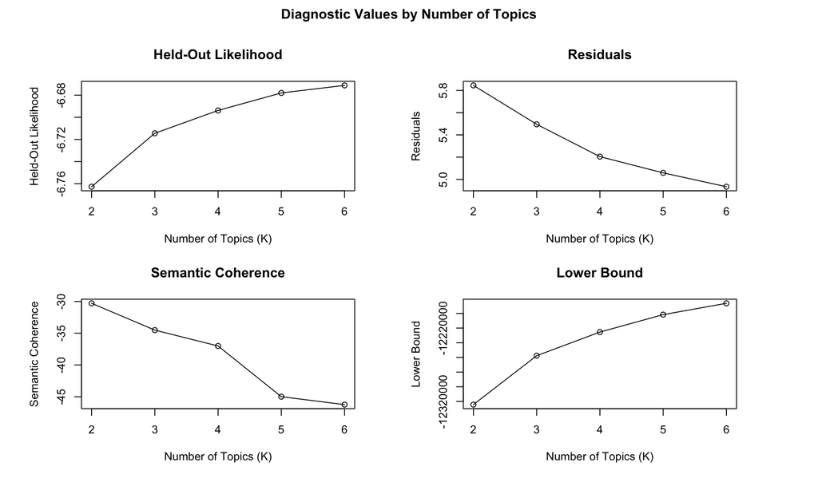

```r
# Use the built-in plot function from STM package
plot(search_results)
```

# Part F: Composite Score Analysis

## (c) Rescaling Metrics to [0, 1]

We normalize both coherence and exclusivity to the [0, 1] scale:

```r
# Extract metrics from search_results using unlist()
metrics_df <- data.frame(
  K = c(2, 3, 4, 5, 6),
  Coherence = unlist(search_results$results$semcoh),
  Exclusivity = unlist(search_results$results$exclus)
)

# Normalize coherence and exclusivity to [0, 1] scale using helper function
metrics_df$Coherence_Norm <- normalize_metric(metrics_df$Coherence)
metrics_df$Exclusivity_Norm <- normalize_metric(metrics_df$Exclusivity)

# Display the rescaled metrics
cat("Rescaled Metrics:\n")
```

```
## Rescaled Metrics:
```

```r
print(metrics_df[, c("K", "Coherence_Norm", "Exclusivity_Norm")])
```

```
##   K Coherence_Norm Exclusivity_Norm
## 1 2     1.00000000        0.0000000
## 2 3     0.73513658        0.3028868
## 3 4     0.57844056        0.5241144
## 4 5     0.07831244        0.8308850
## 5 6     0.00000000        1.0000000
```

## (d) Calculate and Plot Composite Score

**Composite Score = 0.5 × (Rescaled Coherence) + 0.5 × (Rescaled Exclusivity)**

```r
# Calculate composite score with equal weighting (0.5 each)
metrics_df$Composite_Score <- 0.5 * metrics_df$Coherence_Norm + 0.5 * metrics_df$Exclusivity_Norm

# Display the complete metrics table
cat("Metrics Summary with Composite Score:\n")
```

```
## Metrics Summary with Composite Score:
```

```r
print(metrics_df)
```

```
##   K Coherence Exclusivity Coherence_Norm Exclusivity_Norm Composite_Score
## 1 2 -30.28900    7.427381     1.00000000        0.0000000       0.5000000
## 2 3 -34.51234    7.759375     0.73513658        0.3028868       0.5190117
## 3 4 -37.01091    8.001862     0.57844056        0.5241144       0.5512775
## 4 5 -44.98563    8.338113     0.07831244        0.8308850       0.4545987
## 5 6 -46.23435    8.523480     0.00000000        1.0000000       0.5000000
```

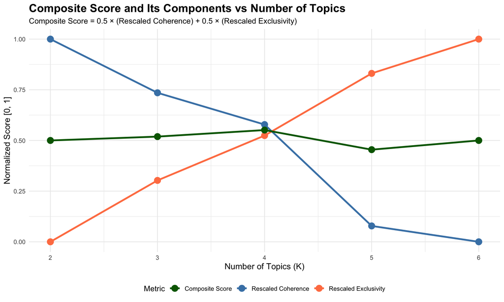

```r
# Plot showing all three metrics: rescaled coherence, rescaled exclusivity, and composite score
ggplot(metrics_df, aes(x = K)) +
  geom_line(aes(y = Coherence_Norm, color = "Rescaled Coherence"), linewidth = 1.2) +
  geom_point(aes(y = Coherence_Norm, color = "Rescaled Coherence"), size = 4) +
  geom_line(aes(y = Exclusivity_Norm, color = "Rescaled Exclusivity"), linewidth = 1.2) +
  geom_point(aes(y = Exclusivity_Norm, color = "Rescaled Exclusivity"), size = 4) +
  geom_line(aes(y = Composite_Score, color = "Composite Score"), linewidth = 1.2) +
  geom_point(aes(y = Composite_Score, color = "Composite Score"), size = 4) +
  scale_color_manual(
    values = c(
      "Rescaled Coherence" = "steelblue",
      "Rescaled Exclusivity" = "coral",
      "Composite Score" = "darkgreen"
    )
  ) +
  scale_x_continuous(breaks = metrics_df$K) +
  labs(
    title = "Composite Score and Its Components vs Number of Topics",
    subtitle = "Composite Score = 0.5 × (Rescaled Coherence) + 0.5 × (Rescaled Exclusivity)",
    x = "Number of Topics (K)",
    y = "Normalized Score [0, 1]",
    color = "Metric"
  ) +
  theme_minimal() +
  theme(
    plot.title = element_text(size = 16, face = "bold"),
    plot.subtitle = element_text(size = 11),
    axis.title = element_text(size = 12),
    legend.position = "bottom"
  )
```

## (e) Plot Composite Score and Select Optimal K

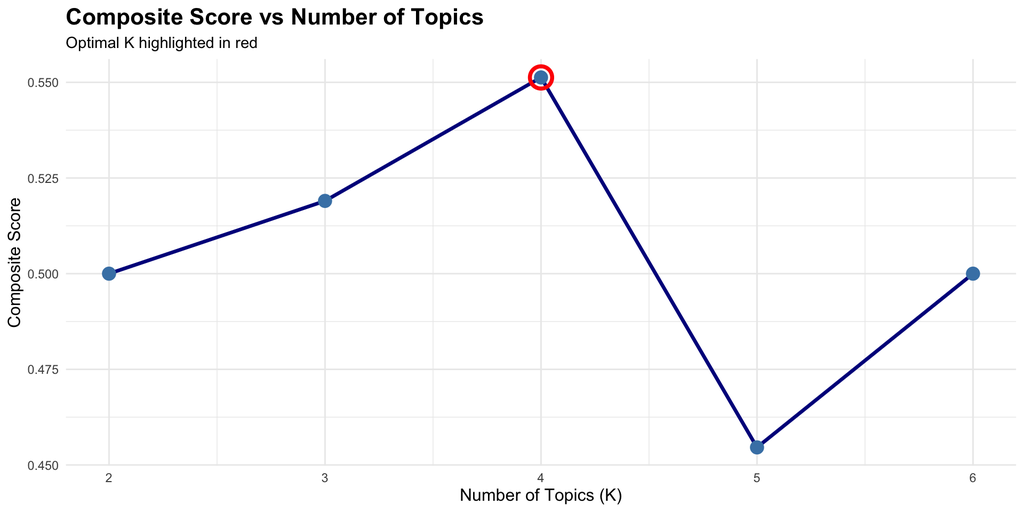

```r
# Create composite score plot focused on optimal K selection
ggplot(metrics_df, aes(x = K, y = Composite_Score)) +
  geom_line(color = "darkblue", linewidth = 1.2) +
  geom_point(size = 4, color = "steelblue") +
  geom_point(
    data = metrics_df[which.max(metrics_df$Composite_Score), ],
    aes(x = K, y = Composite_Score),
    size = 6,
    color = "red",
    shape = 1,
    stroke = 2
  ) +
  scale_x_continuous(breaks = metrics_df$K) +
  labs(
    title = "Composite Score vs Number of Topics",
    subtitle = "Optimal K highlighted in red",
    x = "Number of Topics (K)",
    y = "Composite Score"
  ) +
  theme_minimal() +
  theme(
    plot.title = element_text(size = 16, face = "bold"),
    plot.subtitle = element_text(size = 11),
    axis.title = element_text(size = 12)
  )
```

### Justification for Optimal K

```r
optimal_k <- metrics_df$K[which.max(metrics_df$Composite_Score)]
optimal_score <- max(metrics_df$Composite_Score)

cat(
  "\n**OPTIMAL NUMBER OF TOPICS:** K =", optimal_k, "\n\n",
  "**Composite Score:**", round(optimal_score, 4), "\n\n",
  "**JUSTIFICATION:**\n\n",
  "K =", optimal_k, "maximizes the composite score (", round(optimal_score, 4),
  "), which equally weights rescaled semantic coherence (how often top words co-occur in documents) and exclusivity (how distinctive topics are from each other). This represents the optimal trade-off between interpretable topics and minimal topic overlap.\n\n"
)
```

```
##
## **OPTIMAL NUMBER OF TOPICS:** K = 4
##
##  **Composite Score:** 0.5513
##
##  **JUSTIFICATION:**
##
##  K = 4 maximizes the composite score ( 0.5513 ), which equally weights rescaled semantic coherence (how often top words co-occur in documents) and exclusivity (how distinctive topics are from each other). This represents the optimal trade-off between interpretable topics and minimal topic overlap…
```

# Part G: Final Model Results with Optimal K

## (f) Results for Optimal K

### Fitting STM Model with Optimal K

```r
# Fit the final model with optimal K
optimal_model <- stm(
  documents = docs,
  vocab = vocab,
  K = optimal_k,
  prevalence = ~ rating,
  data = meta,
  max.em.its = 75,
  seed = 42,
  init.type = "Spectral"
)
```

### Top 7 Words for Each Topic

```r
# Extract top words for each topic
optimal_top_words <- labelTopics(optimal_model, n = 7)

cat("Top 7 words for each topic (K =", optimal_k, "):\n\n")
```

```
## Top 7 words for each topic (K = 4 ):
```

```r
for (i in 1:optimal_k) {
  cat("Topic", i, ":\n")
  cat("  FREX words:    ", paste(optimal_top_words$frex[i,], collapse = ", "), "\n")
  cat("  Highest prob:  ", paste(optimal_top_words$prob[i,], collapse = ", "), "\n\n")
}
```

```
## Topic 1 :
##   FREX words:     bali, york, fabul, birthday, wonder, delight, outstand
##   Highest prob:   hotel, stay, staff, great, love, room, servic
##
## Topic 2 :
##   FREX words:     cana, punta, dominican, resort, bavaro, sand, riu
##   Highest prob:   beach, resort, food, pool, good, day, time
##
## Topic 3 :
##   FREX words:     metro, rambla, euro, central, amsterdam, station, subway
##   Highest prob:   hotel, room, locat, stay, good, great, walk
##
## Topic 4 :
##   FREX words:     phone, confirm, stain, carpet, clerk, dirti, credit
##   Highest prob:   room, hotel, stay, night, desk, check, day
```

### Word Clouds for Each Topic

[figure not shown]

```r
# Determine layout based on number of topics
if (optimal_k <= 3) {
  par(mfrow = c(1, optimal_k))
} else if (optimal_k == 4) {
  par(mfrow = c(2, 2))
} else if (optimal_k <= 6) {
  par(mfrow = c(2, 3))
}

# Create word clouds for each topic
for (i in 1:optimal_k) {
  cloud(optimal_model, topic = i, scale = c(3, 0.5), max.words = 50)
  title(paste("Topic", i), line = 1)
}
```

```r
par(mfrow = c(1, 1))
```

### Top Review for Each Topic

```r
# Find top review for each topic
for (i in 1:optimal_k) {
  cat("\n", rep("=", 80), "\n", sep = "")
  cat("Topic", i, "- Top Review:\n")
  cat(rep("=", 80), "\n\n", sep = "")

  thoughts <- findThoughts(optimal_model, texts = reviews, topics = i, n = 1)

  # Safety check: ensure we have valid data
  if (length(thoughts$index[[1]]) == 0 || length(thoughts$docs[[1]]) == 0) {
    cat("No reviews found for this topic.\n\n")
    next
  }

  # Get the index
  index <- thoughts$index[[1]][1]

  cat("Rating:", meta$rating[index], "\n\n")
  cat("Review:\n")
  cat(as.character(thoughts$docs[[1]][1]), "\n\n")
}
```

```
##
## ================================================================================
## Topic 1 - Top Review:
## ================================================================================
##
## Rating: 5
##
## Review:
## total elegance plus week experience elegant welcoming environment totally positive, staff friendly supportive professional times making extra effort ensure stay pleasant possible, suite perfect added touches make feel special, breakfast feast time attentive staff ensure dietary needs catered, ca …
##
##
## ================================================================================
## Topic 2 - Top Review:
## ================================================================================
##
## Rating: 5
##
## Review:
## n't listen reviews, husband couple just returned punta cana march 26th, left started read reviews thought maybe not place go.. wonderful time going, no problems airport, customs pretty easy, just make sure plane blue paper airport save time line, faster coming goingwhen got resort beautiful worke…
##
##
## ================================================================================
## Topic 3 - Top Review:
## ================================================================================
##
## Rating: 4
##
## Review:
## great location adequate well-priced rooms central florence stayed triple room beacci tornabuoni 2 nights friends, biggest plus excellent location historical district, 5 min, walk duomo piazza di signoria uffizi gallery ponte vecchio 10 min, main train station taxi 9 euros, tornabuoni major upmark…
##
##
## ================================================================================
## Topic 4 - Top Review:
## ================================================================================
##
## Rating: 1
##
## Review:
## horrible customer service worst hilton possibly worst hotel, trying review guidelines feel important people know kinds business practices ran into.we stayed hilton nights second night having wedding reception hilton.all booking went smoothly room decent exectutive sweet not overpriced got discoun…
```

### Topic Prevalence for Optimal Model

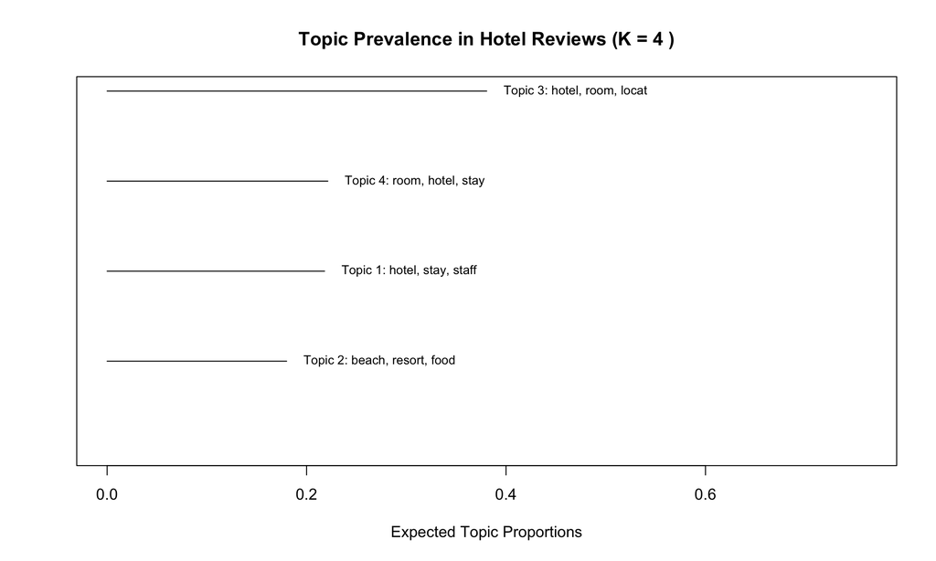

```r
# Plot topic prevalence
plot(optimal_model, type = "summary", text.cex = 0.8,
     main = paste("Topic Prevalence in Hotel Reviews (K =", optimal_k, ")"))
```

# Part H: Summary and Comparison

## Comparison: Problem 1 (K=3) vs Problem 2 (Optimal K)

```r
conclusion <- if (optimal_k == 3) {
  "**CONCLUSION:** The data-driven approach confirms that K = 3 is optimal.\n"
} else {
  paste0("**CONCLUSION:** The data-driven approach suggests K = ", optimal_k, " provides better balance than the fixed K = 3 used in Problem 1.\n")
}

cat(
  "\n**PROBLEM 1: Fixed K = 3 topics**\n\n",
  "- Used selectModel() with multiple random initializations\n",
  "- Selected best model based on semantic coherence and exclusivity\n\n",
  "---\n\n",
  "**PROBLEM 2: Data-driven optimal K =", optimal_k, "topics**\n\n",
  "- Used searchK() to evaluate K = 2, 3, 4, 5, 6\n",
  "- Selected K based on composite score balancing coherence and exclusivity\n",
  "- **Composite Score:**", round(optimal_score, 4), "\n\n",
  "---\n\n",
  conclusion
)
```

```
##
## **PROBLEM 1: Fixed K = 3 topics**
##
##  - Used selectModel() with multiple random initializations
##  - Selected best model based on semantic coherence and exclusivity
##
##  ---
##
##  **PROBLEM 2: Data-driven optimal K = 4 topics**
##
##  - Used searchK() to evaluate K = 2, 3, 4, 5, 6
##  - Selected K based on composite score balancing coherence and exclusivity
##  - **Composite Score:** 0.5513
##
##  ---
##
##  **CONCLUSION:** The data-driven approach suggests K = 4 provides better balance than the fixed K = 3 used in Problem 1.
```

# Reproducibility Information

## Data Summary

```r
cat(
  "**Dataset:** hotel_reviews.csv\n",
  "**Total Reviews:**", nrow(hotel_data), "\n",
  "**Rating Distribution:**\n"
)
```

```
## **Dataset:** hotel_reviews.csv
##  **Total Reviews:** 20491
##  **Rating Distribution:**
```

```r
table(hotel_data$Rating)
```

```
##
##    1    2    3    4    5
## 1421 1793 2184 6039 9054
```

```r
cat("\n**Processing Summary:**\n")
```

```
##
## **Processing Summary:**
```

```r
cat("- Original vocabulary size:", length(processed$vocab), "unique terms\n")
```

```
## - Original vocabulary size: 62535 unique terms
```

```r
cat("- After filtering (lower.thresh = 10):", length(vocab), "unique terms\n")
```

```
## - After filtering (lower.thresh = 10): 6447 unique terms
```

```r
cat("- Documents retained:", length(docs), "out of", length(reviews), "\n")
```

```
## - Documents retained: 20491 out of 20491
```